# February 21, 2022

Last week, we started looking at the `matplotlib` module for plotting.

```python
import matplotlib.pyplot as plt
```

Let's plot $\sin(20x)$ for $x$ between $0$ and $1$, using 100 uniformly spaced subintervals (that is, 101 uniformly spaced endpoints).

First, let's build a list of $x$-values:

```python
xlist = []

N = 100 # number of subintervals

for i in range(N+1):
    xlist.append(i/N)
```

```python
print(xlist)
```

```
[0.0, 0.01, 0.02, 0.03, 0.04, 0.05, 0.06, 0.07, 0.08, 0.09, 0.1, 0.11, 0.12, 0.13, 0.14, 0.15, 0.16, 0.17, 0.18, 0.19, 0.2, 0.21, 0.22, 0.23, 0.24, 0.25, 0.26, 0.27, 0.28, 0.29, 0.3, 0.31, 0.32, 0.33, 0.34, 0.35, 0.36, 0.37, 0.38, 0.39, 0.4, 0.41, 0.42, 0.43, 0.44, 0.45, 0.46, 0.47, 0.48, 0.49, 0.5,…
```

```python
from math import sin

ylist = []

for x in xlist:
    ylist.append(sin(20*x))
```

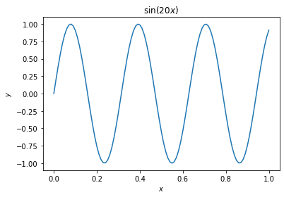

```python
plt.plot(xlist,ylist,'-')
plt.xlabel('$x$')
plt.ylabel('$y$')
plt.title('$\sin(20x)$')
```

Recall: We discussed list comprehension last week for generating lists. Let's generate the same lists using list comprehension:

```python
N = 100 # number of subintervals

xlist = [i/N for i in range(N+1)]
```

```python
print(xlist)
```

```
[0.0, 0.01, 0.02, 0.03, 0.04, 0.05, 0.06, 0.07, 0.08, 0.09, 0.1, 0.11, 0.12, 0.13, 0.14, 0.15, 0.16, 0.17, 0.18, 0.19, 0.2, 0.21, 0.22, 0.23, 0.24, 0.25, 0.26, 0.27, 0.28, 0.29, 0.3, 0.31, 0.32, 0.33, 0.34, 0.35, 0.36, 0.37, 0.38, 0.39, 0.4, 0.41, 0.42, 0.43, 0.44, 0.45, 0.46, 0.47, 0.48, 0.49, 0.5,…
```

```python
ylist = [ sin(20*x) for x in xlist ]
```

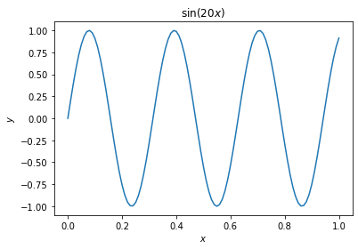

```python
plt.plot(xlist,ylist)
plt.xlabel('$x$')
plt.ylabel('$y$')
plt.title('$\sin(20x)$')
```

Sometimes we want to zoom in on a particular part of our plot. We can set $x$-limits and $y$-limits using the `plt.xlim()` and `plt.ylim()` commands.

`plt.xlim(a,b)` will restrict the plot to where $a \leq x \leq b$.

`plt.ylim(c,d)` will restrict the plot to where $c \leq y \leq d$.

```
(-1.0, -0.25)
```

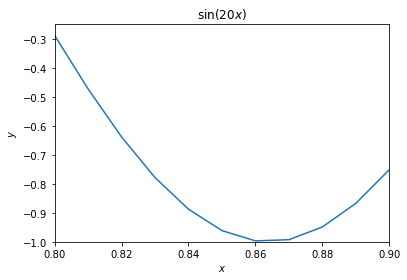

```python
plt.plot(xlist,ylist)
plt.xlabel('$x$')
plt.ylabel('$y$')
plt.title('$\sin(20x)$')

plt.xlim(.8,.9)
plt.ylim(-1,-.25)
```

Plotting circles:

We first will generate a list of angles $\theta$ between $0$ and $2\pi$, dividing the interval $[0,2\pi]$ into $N$ equally spaced subintervals.

```python
from math import sin,cos,pi
```

```python
N = 100  # number of subintervals
R = 1    # radius of the circle

thetalist = [2*pi*i/N for i in range(N+1)]
xlist = [R*cos(theta) for theta in thetalist]
ylist = [R*sin(theta) for theta in thetalist]
```

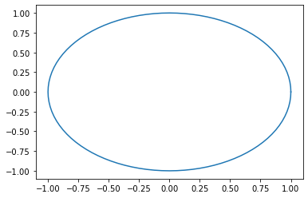

```python
plt.plot(xlist,ylist)
```

The above plot does not look very circular... by default `matplotlib` does not force a 1:1 aspect ratio. We can fix this using the `plt.axis('equal')` command.

```
(-1.1, 1.1, -1.1, 1.1)
```

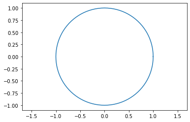

```python
plt.plot(xlist,ylist)
plt.axis('equal')
```

# The Collatz Conjecture

Consider the function $$ f(n) = \begin{cases} 3n+1 & \text{if $n$ is odd} \\ n/2 & \text{if $n$ is even} \end{cases} $$

For any starting $n$, we generate a sequence $\{a_i\}$ where $$ a_0 = n, \qquad a_{i+1} = f(a_i) \quad \text{for i = 0,1,2,}\cdots $$

```python
def f(n):
    if n%2 == 1:
        return 3*n+1
    else:
        return n//2
```

```python
f(5)
```

```
16
```

```python
f(16)
```

```
8
```

```python
f(8)
```

```
4
```

```python
f(4)
```

```
2
```

```python
f(2)
```

```
1
```

```python
f(1)
```

```
4
```

```python
f(4)
```

```
2
```

```python
f(2)
```

```
1
```

The Collatz conjecture states that for any starting positive integer $n$, the sequence eventually reaches 1.

**Exercise.** Define a function `collatz(n)` that generates the sequence of values $\{a_i\}$ where $a_0 = n$ and $a_{i+1} = f(a_i)$, stopping when the sequence reaches 1.

```python
def collatz(n):
    orbit = [n]
    while True:
        ai = orbit[-1] # most recent number in the sequence
        fai = f(ai)    # find the next entry in the sequence
        orbit.append(fai)
        if fai == 1:
            break
    return orbit
```

We can clean this up slightly:

```python
def collatz(n):
    orbit = [n]
    while not orbit[-1] == 1:
        orbit.append(f(orbit[-1]))
    return orbit
```

```python
collatz(32)
```

```
[32, 16, 8, 4, 2, 1]
```

Let's look at these orbits for many numbers:

```python
orbits = []

N = 10**5

nlist = [n for n in range(1,N)]

for n in nlist:
    orbits.append(collatz(n))
```

```python
orbits[4]
```

```
[5, 16, 8, 4, 2, 1]
```

One trick for simultaneously iterating through multiple lists is to use the `zip()` function.

```python
for i,j in zip([1,2,3],[4,5,6]):
    print(i,j)
```

```
1 4
2 5
3 6
```

In our case, we can zip together the `nlist` and the `orbits`.

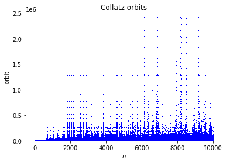

```python
for n,orbit in zip(nlist,orbits):
    x = [n for i in range(len(orbit))]
    plt.plot(x,orbit,'b,')
    if n > 10**4:
        break  # plotting seems slow, so let's stop after the first 10,000
plt.ylim(0,25*10**5)

plt.xlabel('$n$')
plt.ylabel('orbit')
plt.title('Collatz orbits')
```

Let's look at $n$ versus the largest number in its orbit. We can use the `max()` function to find the largest element in each orbit.

```python
max([1,2,3,5])
```

```
5
```

```python
min([1,2,3,5])
```

```
1
```

```python
orbit_maxs = [max(orbit) for orbit in orbits]
```

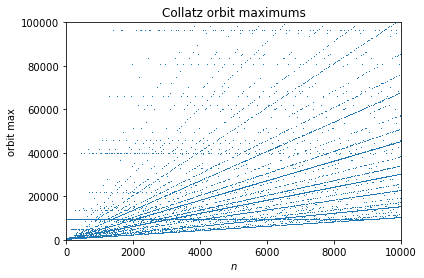

```python
plt.plot(nlist,orbit_maxs,',')
plt.xlim(0,10**4)
plt.ylim(0,10**5)

plt.xlabel('$n$')
plt.ylabel('orbit max')
plt.title('Collatz orbit maximums')
```

Another idea is to look at the length of each orbit.

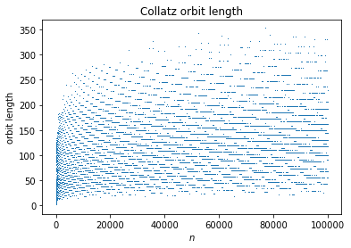

```python
orbit_lengths = [len(orbit) for orbit in orbits]

plt.plot(nlist,orbit_lengths,',')

plt.xlabel('$n$')
plt.ylabel('orbit length')
plt.title('Collatz orbit length')
```

# Project 2 - Pythagorean triples

[see course webpage](https://jllottes.github.io/Projects/pythagorean_triples/pythagorean_triples.html)

A tuple of integers $(a,b,c)$ is a **Pythagorean triple** if $a^2 + b^2 = c^2$.

Let's start with a function that takes in an integer and checks if it is a perfect square.

```python
from math import sqrt

def is_square(n):
    if sqrt(n) == round(sqrt(n)):
        return True
    else:
        return False
```

```python
is_square(4)
```

```
True
```

This looks like it's working, but it's always risky to check whether two floats are equal to one another. Another approach that is slightly safer:

First, compute $\sqrt{n}$. Then take the integer part of $\sqrt{n}$. Then square the result and check if it is equal to $n$.

```python
def is_square(n):
    if int(sqrt(n)) ** 2 == n:
        return True
    else: return False
```

```python
is_square(4)
```

```
True
```

There is still a possible complication if Python evaluated something like `sqrt(9.0) = 2.99999999`. We can get around this by adding say `0.5` to `sqrt(n)` before truncating to make up for any slight under estimation of the square root.

```python
def is_square(n):
    if int(sqrt(n) + 0.5) ** 2 == n:
        return True
    else: return False
```

```python
is_square(9)
```

```
True
```

## Part 1:

Write a function `ptriples(n)` that takes an positive number `n` and generates a list of all Pythagorean triples `(a,b,c)` where $1 \leq a,b \leq n$.

Let's compare zipped iteration versus nested iteration:

```python
for i,j in zip([1,2,3],['a','b','c']):
    print(i,j)
```

```
1 a
2 b
3 c
```

```python
for i in [1,2,3]:
    for j in ['a','b','c']:
        print(i,j)
```

```
1 a
1 b
1 c
2 a
2 b
2 c
3 a
3 b
3 c
```

# February 23, 2022

```python
mylist = ['a','b','c','d']

for i in range(len(mylist)):
    c = mylist[i]
    print(c)
```

```
a
b
c
d
```

```python
for c in mylist:
    print(c)
```

```
a
b
c
d
```

```python
for i,c in enumerate(mylist):
    print(i,c)
```

```
0 a
1 b
2 c
3 d
```

```python
mylist = [[1,2,3],
          [4,5,6],
          [7,8,9],
          [10,11,12]]

[ triple[0] for triple in mylist ]
```

```
[1, 4, 7, 10]
```

## The greatest common divisor

The greater common divisor of two integers $a$ and $b$ is the greatest integer that divides both $a$ and $b$. We denote it by $\gcd(a,b)$.

If $\gcd(a,b)=1$, then we say that $a$ and $b$ are relatively prime.

One method of finding $\gcd(a,b)$ is to brute-force check every possible divisor, then take the maximum of all divisors.a

```python
def gcd(a,b):
    divisors = []
    for d in range(1,min(a,b)+1):
        if a % d == 0 and b % d == 0:
            divisors.append(d)
    return max(divisors)
```

```python
gcd(12,18)
```

```
6
```

## The Euclidean algorithm for computing the gcd

(see wikipedia article)

- Start with two integers $a$, $b$
- Subtract the smaller number from the larger and replace the larger with this new number
- Repeat the above step until one of the numbers is 0
- the other number is the $\gcd(a,b)$.

**Exercise.** Create a function `gcd(a,b)` that implements the above algorithm to find $\gcd(a,b)$.

```python
a = 1
b = 3

print(a,b)

a,b = b,a

print(a,b)
```

```
1 3
3 1
```

## Back to Pythagorean triples:

We call a Pythagorean triple $(a,b,c)$ a **primitive Pythagorean triple** if $a$ and $b$ are relatively prime.